# Data visualization with Kandy

Kotlin offers an all-in-one-place solution for powerful and flexible data visualization, providing an intuitive way to present and explore data before diving into complex models.

This tutorial demonstrates how to create different chart types in IntelliJ IDEA using the [Kandy](https://kotlin.github.io/kandy/welcome.html) and [Kotlin DataFrame](https://kotlin.github.io/dataframe/home.html) libraries.

## Before you start

To follow this tutorial:

1. Select File | New | Kotlin Notebook.
2. In your notebook, import [Kandy](https://kotlin.github.io/kandy/welcome.html) and [Kotlin DataFrame](https://kotlin.github.io/dataframe/home.html):

   ```
   %use kandy
   %use dataframe
   ```

   Run the code cell with the `%use dataframe` line before any other code cells to make sure the DataFrame library and its APIs are available in the notebook.

To follow the tutorial, you can also use DataFrame as a [Gradle](https://kotlin.github.io/dataframe/setupgradle.html) or [Maven](https://kotlin.github.io/dataframe/setupmaven.html) dependency.

## Create a DataFrame

To start, let's create a DataFrame with data to visualize. This DataFrame stores simulated monthly average temperatures for Berlin, Madrid, and Caracas:

```
// The months variable stores a list with the 12 months of the year
val months = listOf(
    "January", "February",
    "March", "April", "May",
    "June", "July", "August",
    "September", "October", "November",
    "December"
)
// The tempBerlin, tempMadrid, and tempCaracas variables store a list
// with temperature values for each month
val tempBerlin =
    listOf(-0.5, 0.0, 4.8, 9.0, 14.3, 17.5, 19.2, 18.9, 14.5, 9.7, 4.7, 1.0)
val tempMadrid =
    listOf(6.3, 7.9, 11.2, 12.9, 16.7, 21.1, 24.7, 24.2, 20.3, 15.4, 9.9, 6.6)
val tempCaracas =
    listOf(27.5, 28.9, 29.6, 30.9, 31.7, 35.1, 33.8, 32.2, 31.3, 29.4, 28.9, 27.6)
```

Now let's create a new variable (`df`) and use the [`dataFrameOf()`](https://kotlin.github.io/dataframe/createdataframe.html#dataframeof) function to generate a DataFrame of three columns (Month, Temperature, and City):

```
val df = dataFrameOf(
    "Month" to months + months + months,
    "Temperature" to tempBerlin + tempMadrid + tempCaracas,
    "City" to List(12) { "Berlin" } + List(12) { "Madrid" } + List(12) { "Caracas" }
)
```

To preview the data, use the [`.head()`](https://kotlin.github.io/dataframe/head.html) function:

```
df.head(4) // Returns the first four rows
```

In our dataset, the first four rows store temperature in Berlin from January to April:

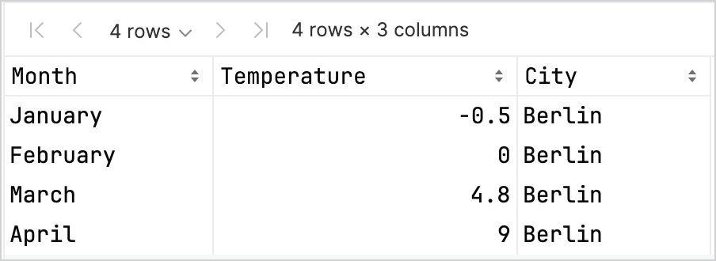

## Create a line chart

Let's create a line chart using the `df` DataFrame from the previous section:

1. Call the `.plot()` function from the Kandy library.
2. Apply the `line()` layer.
3. Map the `Month` and `Temperature` columns to the `X` and `Y` axes accordingly.
4. (Optional) Customize colors and sizes.

```
df.plot {
   line {
      x(Month)
      y(Temperature)

      color(City) {
         scale = categorical(
            "Berlin" to Color.hex("#6F4E37"),
            "Madrid" to Color.hex("#C2D4AB"),
            "Caracas" to Color.hex("#B5651D")
         )
      }
      width = 1.5
   }
   layout {
      size = 1000 to 450
   }
}
```

Here's the result:

[figure not shown]

## Create a points chart

Now, let's visualize the `df` DataFrame in a points (scatter) chart:

1. Call the `.plot()` function from the Kandy library.
2. Apply the `points()` layer.
3. Map the `Month` and `Temperature` columns to the `X` and `Y` axes accordingly.
4. (Optional) Customize colors, axis labels, point sizes, and chart title.

```
df.plot {
   points {
      x(Month) {
         axis.name = "Month"
      }
      y(Temperature) {
         axis.name = "Temperature"
      }

      color(City) {
         scale = categorical(
            "Berlin" to Color.hex("#6F4E37"),
            "Madrid" to Color.hex("#C2D4AB"),
            "Caracas" to Color.hex("#B5651D")
         )
      }
      size = 5.5
   }
   layout {
      title = "Temperature per month"
   }
}
```

Here's the result:

[figure not shown]

## Create a bar chart

Finally, let's create a bar chart for each city:

1. Use the `.groupBy()` function to group the DataFrame by the `City` column.
2. Call the `plot()` function from the Kandy library.
3. Apply the `bars()` layer.
4. (Optional) Add a title for the chart, customize colors.

```
df.groupBy { City }.plot {
    bars {
        x(Month)
        y(Temperature)

        fillColor(City) {
            scale = categorical(
                "Berlin" to Color.hex("#6F4E37"),
                "Madrid" to Color.hex("#C2D4AB"),
                "Caracas" to Color.hex("#B5651D")
            )
        }
    }
    layout.title {
       title = "Temperature per month"
    }
}
```

Here's the result:

[figure not shown]

## What's next

- Explore more chart examples in the [Kandy library documentation](https://kotlin.github.io/kandy/examples.html)
- Explore more advanced plotting options in the Lets-Plot library documentation
- Find additional information about creating, exploring, and managing data frames in the [Kotlin DataFrame library documentation](https://kotlin.github.io/dataframe/info.html)

29 June 2026